# **TUGAS MPDW PERTEMUAN 6**

Joshua Bryan Wijaya~G1401231082

2025-10-3

# **LIBRARY**

```r
library(forecast)
```

```r
library(graphics)
library(TTR)
library(TSA)
library(dplyr)
library(rio)
library(readxl)
library(ggplot2)
library(tsibble)
library(tseries)
library(MASS)
```

# **DATA**

```r
data <- read_xlsx("C:/JOSHUA BRYAN WIJAYA/SEMESTER 5/MPDW/Joshua.xlsx")
summary(data)
```

```
##       date                       temp_mean          part
##  Min.   :2024-12-20 00:00:00   Min.   :24.00   Min.   :4
##  1st Qu.:2025-02-20 06:00:00   1st Qu.:25.40   1st Qu.:4
##  Median :2025-04-23 12:00:00   Median :25.80   Median :4
##  Mean   :2025-04-23 12:00:00   Mean   :25.81   Mean   :4
##  3rd Qu.:2025-06-24 18:00:00   3rd Qu.:26.30   3rd Qu.:4
##  Max.   :2025-08-26 00:00:00   Max.   :27.80   Max.   :4
##                                NA's   :2
```

```r
head(data)
```

```
## # A tibble: 6 × 3
##   date                temp_mean  part
##   <dttm>                  <dbl> <dbl>
## 1 2024-12-20 00:00:00      25.9     4
## 2 2024-12-21 00:00:00      26.2     4
## 3 2024-12-22 00:00:00      25.5     4
## 4 2024-12-23 00:00:00      25.6     4
## 5 2024-12-24 00:00:00      25       4
## 6 2024-12-25 00:00:00      25.3     4
```

Data yang digunakan adalah data rataan temperatur di Kab. Bogor, dimulai dari rentang waktu 20 Desember 2024 hingga 26 Agustus 2025

# **EKSPLORASI DATA**

```r
data <- data %>% dplyr::select(date,temp_mean)
str(data)
```

```
## tibble [250 × 2] (S3: tbl_df/tbl/data.frame)
##  $ date     : POSIXct[1:250], format: "2024-12-20" "2024-12-21" ...
##  $ temp_mean: num [1:250] 25.9 26.2 25.5 25.6 25 25.3 26.4 26.5 27.2 26.2 ...
```

```r
dim(data)
```

```
## [1] 250   2
```

```r
colSums(is.na(data))
```

```
##      date temp_mean
##         0         2
```

```r
data[!complete.cases(data), ]
```

```
## # A tibble: 2 × 2
##   date                temp_mean
##   <dttm>                  <dbl>
## 1 2025-08-25 00:00:00        NA
## 2 2025-08-26 00:00:00        NA
```

Ditemukan 2 amatan yang null alias tidak memiliki nilai. Selanjutnya, untuk menangani hal ini, akan dilakukan imputasi nilai menggunakan rataan dari seluruh nilai temp_mean.

# **IMPUTASI DATA KOSONG**

```r
mean_val <- mean(data$temp_mean, na.rm = TRUE)
data$temp_mean[is.na(data$temp_mean)] <- mean_val

colSums(is.na(data))
```

```
##      date temp_mean
##         0         0
```

```r
data[!complete.cases(data), ]
```

```
## # A tibble: 0 × 2
## # ℹ 2 variables: date <dttm>, temp_mean <dbl>
```

Setelah dilakukan imputasi data, tidak lagi ditemukan nilai kosong pada data. Imputasi nilai kosong dilakukan dengan menggunakan nilai rataan dari Yt(temperature_mean). Sekarang data sudah siap untuk dianalisis dengan metode smoothing

# **TEST X TRAIN**

```r
data.ts <- ts(data$temp_mean)
n <- nrow(data)
n_train <- floor(0.8*n)
training_ma <- data[1:n_train,]
testing_ma <- data[(n_train+1):n,]
train_ma.ts<- ts(training_ma$temp_mean)
test_ma.ts<- ts(testing_ma$temp_mean)
```

Data di split dengan rasio data latih:data uji 80:20. Selanjutnya, untuk pengecekan kestasioneran data, akan dilakukan hanya pada data latih saja (karena data latih yang digunakan untuk membentuk model kedepannya).

# **UJI DATA LATIH SAJA**

```r
head(train_ma.ts)
```

```
## Time Series:
## Start = 1
## End = 6
## Frequency = 1
## [1] 25.9 26.2 25.5 25.6 25.0 25.3
```

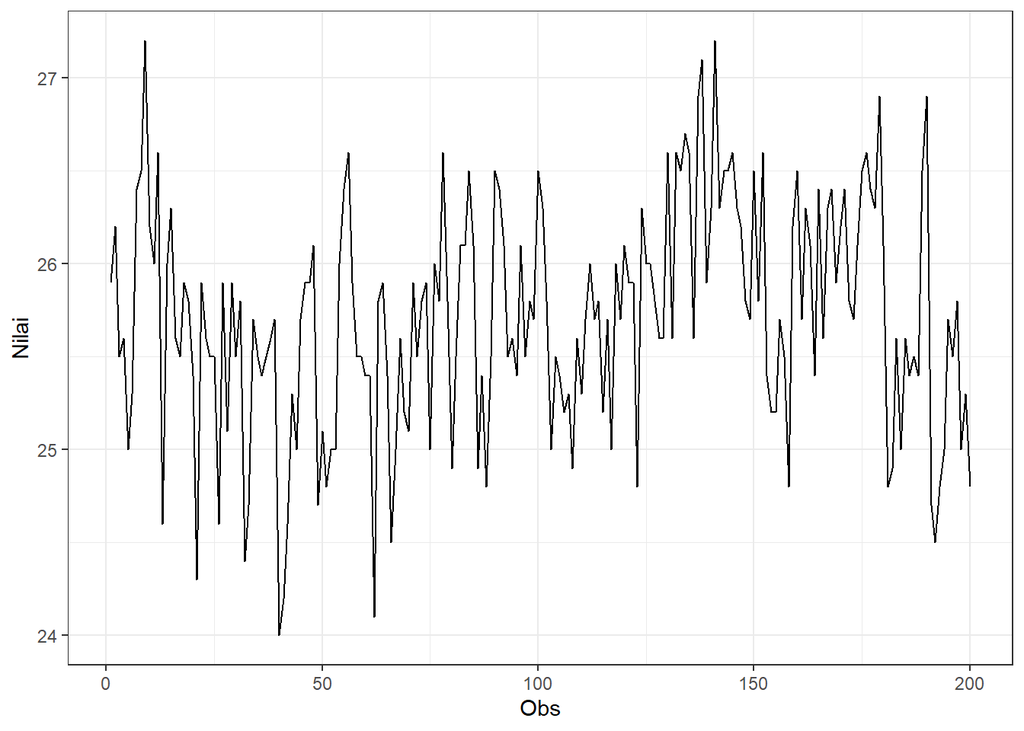

```r
plot_data <- train_ma.ts |> as_tsibble() |>
  ggplot(aes(x = index, y = value)) + geom_line() + theme_bw() +
  xlab("Obs") + ylab("Nilai")
plot_data
```

Terlihat pada plot time series, data train (data latih) cenderung bergerak di sekitar nilai tengah yang sama, serta fluktuasi/amplitudo di setiap amatan terlihat konstan. Hasil ini mendindikasikan bahwa data cenderung stasioner dalam rataan dan ragam.

# **EKSPLORASI KESTASIONERAN DATA LATIH**

## **Kestasioneran dalam Rataan**

```r
mean(train_ma.ts)
```

```
## [1] 25.706
```

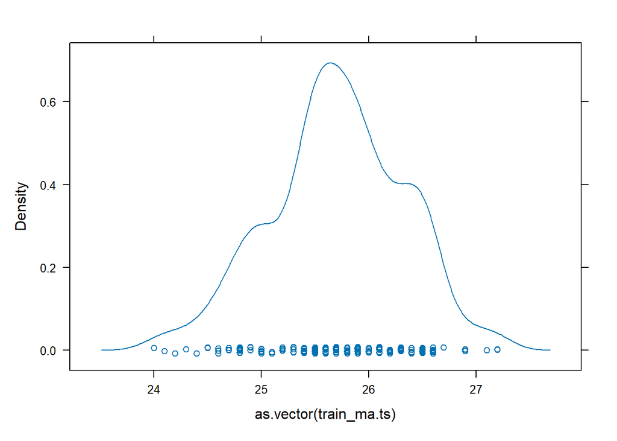

```r
lattice::densityplot(as.vector(train_ma.ts))
```

Diperoleh nilai rata-rata sebesar 25.706. Dari density plot data, terlihat bahwa data cenderung berkumpul di angka 25.5 hingga 26. Ini bisa jadi pertanda baik untuk kestasioneran dalam rataan. Namun, uji lanjutan tetap perlu dilakukan.

## **Plot ACF**

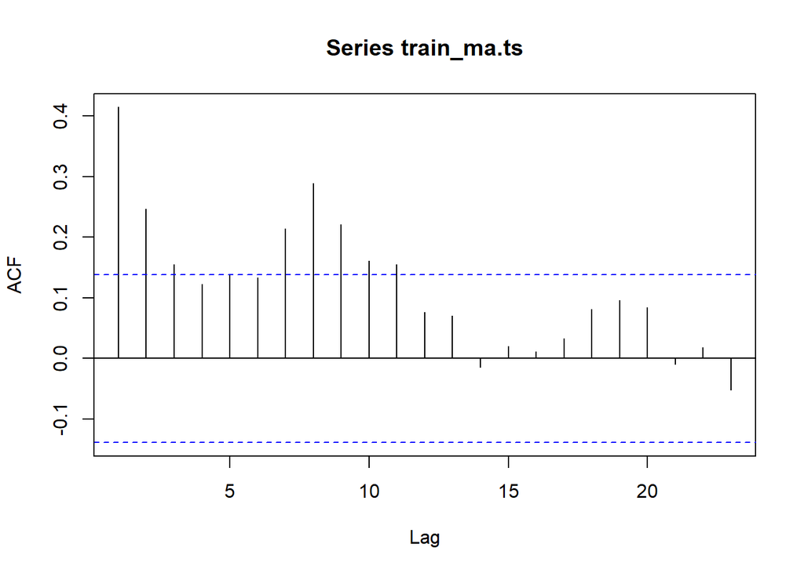

```r
acf(train_ma.ts)
```

Terlihat bahwa plot ACF di atas membentuk pola *tails off* cukup panjang (turun perlahan). Hasil plot ACF baru terlihat tidak signifikan pada lag 4, dan dari lag 19 hingga seterusnya, terlihat adanya kecenderungan untuk membentuk pola gelombang sinus.Dari sini, terlihat bahwa data masih punya kecenderungan pola tren yang tentunya harus diselidiki lebih lanjut dengan uji formal. Dan Plot ACF terlihat dimulai dari lag 1, bukan lag 0.

## **Uji ADF**

$H_0$ : Data Tidak Stasioner dalam Rataan  
$H_1$ : Data Stasioner dalam Rataan

```r
tseries::adf.test(train_ma.ts)
```

```
##
##  Augmented Dickey-Fuller Test
##
## data:  train_ma.ts
## Dickey-Fuller = -4.0634, Lag order = 5, p-value = 0.01
## alternative hypothesis: stationary
```

Terlihat bahwa hasil uji ADF menunjukkan nilai $P - Value < 0.05$. Sehingga keputusan yang diambil adalah tolak $H_0$. Artinya, **data stasioner dalam rataan**. Hasil ini sedikit berbeda dengan plot time series dan plot ACF sebelumnya.

# **KESTASIONERAN DATA LATIH DALAM RAGAM**

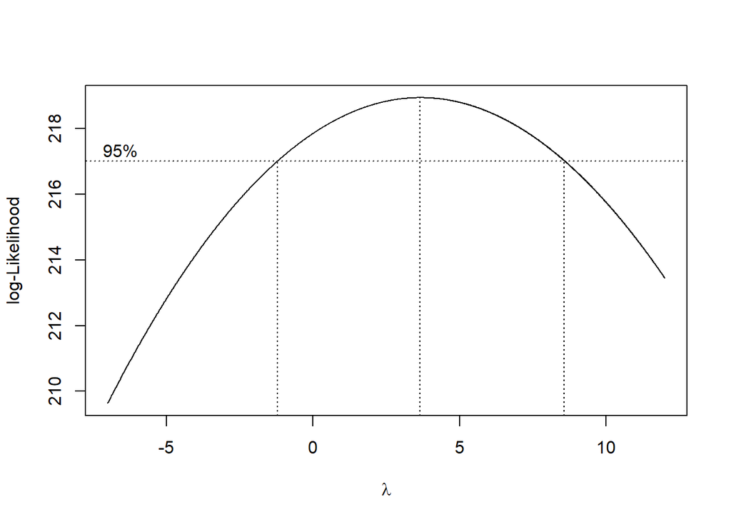

```r
index <- seq(1:200)
bc <- boxcox(
  train_ma.ts ~ index,
  lambda = seq(-7, 12, by = 0.01)
)
```

```r
lambda <- bc$x[which.max(bc$y)]
cat("Lambda Optimum: ", lambda)
```

```
## Lambda Optimum:  3.66
```

```r
ci_lambda <- bc$x[bc$y > max(bc$y) - 0.5 * qchisq(0.95, 1)]
ci_lower <- min(ci_lambda)
ci_upper <- max(ci_lambda)

c(Batas_Bawah = ci_lower, Batas_Atas = ci_upper)
```

```
## Batas_Bawah  Batas_Atas
##       -1.20        8.57
```

Terlihat bahwa selang kepercayaan untuk lambda memiliki batas bawah -1.2, dan batas atas 8.57. Hal ini menunjukkan bahwa **lambda = 1** terdapat dalam selang. Hasil ini dapat diartikan bahwa **data stasioner dalam ragam**

# **SPESIFIKASI MODEL**

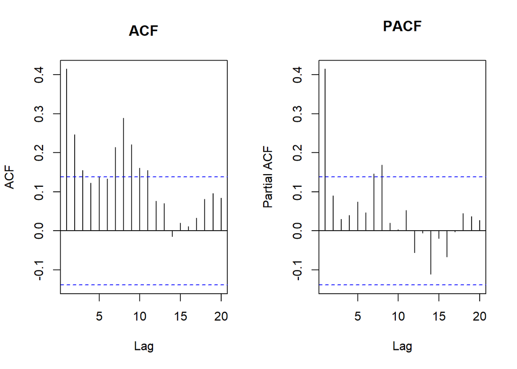

```r
par(mfrow = c(1,2))
acf(train_ma.ts, main="ACF", lag.max=20)
pacf(train_ma.ts, main="PACF", lag.max=20)
```

Setelah dilakukan visualisasi pada data latih menggunakan ACF dan PACF, terlihat bahwa pada plot ACF, *cuts off* setelah lag 3. Model yang potensial adalah ARIMA(3,0,0)(walau sebenarnya masih kurang tepat juga jika dikatakan *cuts off*, karena didepannya masih ada lag yang signifikan dan grafik ACFnya condong ke tails off).Selanjutnya pada plot PACF, terlihat bahwa *cuts off* terjadi setelah lag pertama. Model yang potensial adalah ARIMA(1,0,0).

```r
eacf(train_ma.ts)
```

```
## AR/MA
##   0 1 2 3 4 5 6 7 8 9 10 11 12 13
## 0 x x x o o o x x x x x  o  o  o
## 1 x o o o o o o o o o o  o  o  o
## 2 x o o o o o o o o o o  o  o  o
## 3 x o o o o o o o o o o  o  o  o
## 4 x x o o o o o o o o o  o  o  o
## 5 x x o o o o o o o o o  o  o  o
## 6 x x x o x o o o o o o  o  o  o
## 7 x x x x o o o o o o o  o  o  o
```

Menggunakan plot EACF, dapat ditemukan beberapa model potensial dengan melihat ujung segitiga yang terbentuk, antara lain ARIMA(0,0,3), ARIMA(1,0,1), ARIMA(2,0,1), ARIMA(3,0,1)

# **PENDUGAAN PARAMETER DAN SELEKSI ORDO MODEL**

## **ARIMA(0,0,3)**

```r
model1=Arima(train_ma.ts, order=c(0,0,3),method="ML")
summary(model1)
```

```
## Series: train_ma.ts
## ARIMA(0,0,3) with non-zero mean
##
## Coefficients:
##          ma1     ma2     ma3     mean
##       0.3774  0.2032  0.0950  25.7038
## s.e.  0.0708  0.0689  0.0711   0.0664
##
## sigma^2 = 0.3226:  log likelihood = -168.73
## AIC=347.47   AICc=347.78   BIC=363.96
##
## Training set error measures:
##                         ME      RMSE       MAE         MPE     MAPE      MASE
## Training set -0.0005204233 0.5622941 0.4445428 -0.05068748 1.734795 0.8597087
##                     ACF1
## Training set 0.007227078
```

```r
lmtest::coeftest(model1)
```

```
##
## z test of coefficients:
##
##            Estimate Std. Error  z value  Pr(>|z|)
## ma1        0.377444   0.070777   5.3329 9.667e-08 ***
## ma2        0.203218   0.068874   2.9506  0.003172 **
## ma3        0.094998   0.071115   1.3358  0.181605
## intercept 25.703762   0.066416 387.0127 < 2.2e-16 ***
## ---
## Signif. codes:  0 '***' 0.001 '**' 0.01 '*' 0.05 '.' 0.1 ' ' 1
```

## **ARIMA (1,0,1)**

```r
model2=Arima(train_ma.ts, order=c(1,0,1),method="ML")
summary(model2)
```

```
## Series: train_ma.ts
## ARIMA(1,0,1) with non-zero mean
##
## Coefficients:
##          ar1      ma1     mean
##       0.6293  -0.2621  25.7023
## s.e.  0.1471   0.1885   0.0783
##
## sigma^2 = 0.3182:  log likelihood = -167.86
## AIC=343.73   AICc=343.93   BIC=356.92
##
## Training set error measures:
##                         ME      RMSE       MAE         MPE     MAPE      MASE
## Training set -0.0009473379 0.5598119 0.4431986 -0.05154862 1.729889 0.8571091
##                    ACF1
## Training set 0.00884576
```

```r
lmtest::coeftest(model2)
```

```
##
## z test of coefficients:
##
##            Estimate Std. Error  z value  Pr(>|z|)
## ar1        0.629317   0.147139   4.2770 1.894e-05 ***
## ma1       -0.262087   0.188533  -1.3901    0.1645
## intercept 25.702300   0.078294 328.2773 < 2.2e-16 ***
## ---
## Signif. codes:  0 '***' 0.001 '**' 0.01 '*' 0.05 '.' 0.1 ' ' 1
```

Menggunakan ordo ARIMA (1,0,1) atau setara ARMA(1,1), diperoleh **AIC = 343.73**. Kemudian, terdapat peubah/parameter yang tidak signifikan, yaitu ma1.

## **ARIMA(2,0,1)**

```r
model3=Arima(train_ma.ts, order=c(2,0,1),method="ML")
summary(model3)
```

```
## Series: train_ma.ts
## ARIMA(2,0,1) with non-zero mean
##
## Coefficients:
##          ar1      ar2      ma1     mean
##       1.2065  -0.2506  -0.8555  25.6919
## s.e.  0.1103   0.0875   0.0802   0.1226
##
## sigma^2 = 0.3128:  log likelihood = -165.7
## AIC=341.41   AICc=341.72   BIC=357.9
##
## Training set error measures:
##                        ME      RMSE       MAE         MPE     MAPE      MASE
## Training set -0.003022802 0.5536251 0.4408921 -0.05864707 1.721123 0.8526485
##                     ACF1
## Training set 0.002834972
```

```r
lmtest::coeftest(model3)
```

```
##
## z test of coefficients:
##
##            Estimate Std. Error  z value  Pr(>|z|)
## ar1        1.206473   0.110308  10.9373 < 2.2e-16 ***
## ar2       -0.250587   0.087467  -2.8649  0.004171 **
## ma1       -0.855457   0.080226 -10.6631 < 2.2e-16 ***
## intercept 25.691940   0.122622 209.5223 < 2.2e-16 ***
## ---
## Signif. codes:  0 '***' 0.001 '**' 0.01 '*' 0.05 '.' 0.1 ' ' 1
```

Menggunakan ordo ARIMA (2,0,1) atau setara ARMA(2,1), diperoleh **AIC = 341.41**. Kemudian, seluruh peubah/parameternya signifikan.

## **ARIMA(3,0,1)**

```r
model4=Arima(train_ma.ts, order=c(3,0,1),method="ML")
summary(model4)
```

```
## Series: train_ma.ts
## ARIMA(3,0,1) with non-zero mean
##
## Coefficients:
##          ar1      ar2     ar3      ma1     mean
##       1.2057  -0.2555  0.0051  -0.8535  25.6925
## s.e.  0.1117   0.1120  0.0763   0.0870   0.1228
##
## sigma^2 = 0.3143:  log likelihood = -165.7
## AIC=343.4   AICc=343.84   BIC=363.19
##
## Training set error measures:
##                        ME      RMSE       MAE         MPE     MAPE     MASE
## Training set -0.003231208 0.5536158 0.4409658 -0.05945473 1.721421 0.852791
##                     ACF1
## Training set 0.001363022
```

```r
lmtest::coeftest(model4)
```

```
##
## z test of coefficients:
##
##             Estimate Std. Error  z value Pr(>|z|)
## ar1        1.2057285  0.1117345  10.7910  < 2e-16 ***
## ar2       -0.2554955  0.1120070  -2.2811  0.02254 *
## ar3        0.0051357  0.0762730   0.0673  0.94632
## ma1       -0.8535332  0.0869694  -9.8142  < 2e-16 ***
## intercept 25.6925213  0.1227692 209.2750  < 2e-16 ***
## ---
## Signif. codes:  0 '***' 0.001 '**' 0.01 '*' 0.05 '.' 0.1 ' ' 1
```

Menggunakan ordo ARIMA (3,0,1) atau setara ARMA(3,1), diperoleh **AIC = 343.4**. Kemudian, terdapat peubah/parameter yang tidak signifikan, yaitu ar3.

## **Perbandingan semua model**

```r
hasil_model <- data.frame(
  Model = c("ARIMA(0,0,3)",
            "ARIMA(1,0,1)",
            "ARIMA(2,0,1)",
            "ARIMA(3,0,1)"),
  AIC = c(
    AIC(model1),
    AIC(model2),
    AIC(model3),
    AIC(model4)
  ),
  BIC = c(
    BIC(model1),
    BIC(model2),
    BIC(model3),
    BIC(model4)
  )
)

hasil_model
```

```
##          Model      AIC      BIC
## 1 ARIMA(0,0,3) 347.4688 363.9604
## 2 ARIMA(1,0,1) 343.7285 356.9218
## 3 ARIMA(2,0,1) 341.4063 357.8979
## 4 ARIMA(3,0,1) 343.4017 363.1916
```

Karena model 3, yakni ARIMA(2,0,1) memiliki AIC terkecil, BIC relatif rendah, dan seluruh peubah/parameternya signifikan, maka ARIMA(2,0,1) dipilih sebagai model prediksi.

# **ANALISIS SISAAN MODEL TERBAIK**

## **Eksplorasi Sisaan**

```r
sisaan <- model3$residuals
```

```r
par(mfrow=c(2,2))
car::qqPlot(sisaan)
```

```
## [1] 40 13
```

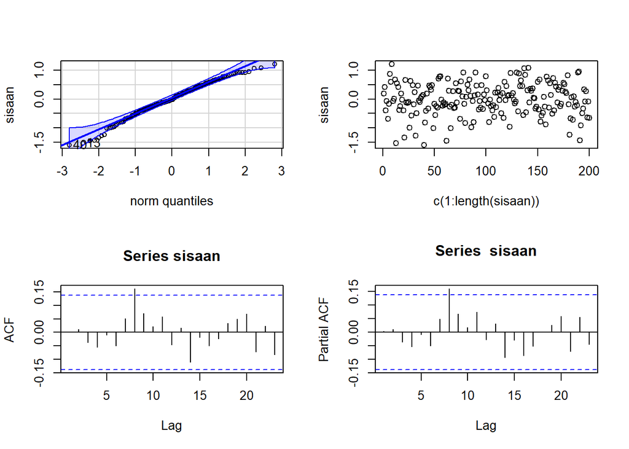

```r
plot(c(1:length(sisaan)),sisaan)
acf(sisaan)
pacf(sisaan)
```

Berdasarkan plot kuantil-kuantil normal, secara eksplorasi ditunjukkan sisaan menyebar normal mengikuti garis sudut $\pi/4$. Kemudian dapat dilihat juga lebar pita sisaan yang cenderung sama menandakan bahwa sisaan memiliki ragam yang homogen. Akan tetapi, plot ACF dan PACF sisaan ARIMA(2,0,1) signifikan pada lag ke-8 sehingga **sisaan tidak saling bebas**. Kondisi ini akan diuji lebih lanjut dengan uji formal.

# **UJI FORMAL LANJUTAN**

## **Normalitas**

$H_0$ : Sisaan menyebar normal  
$H_1$ : Sisaan tidak menyebar normal

```r
ks.test(sisaan,"pnorm")
```

```
##
##  Asymptotic one-sample Kolmogorov-Smirnov test
##
## data:  sisaan
## D = 0.1564, p-value = 0.0001127
## alternative hypothesis: two-sided
```

Uji formal menggunakan uji Kolmogorov-Smirnov menunjukkan bahwa data residual model tidak menyebar normal, karena memiliki *p-value* < $\alpha$ (5%) sehingga tolak $H_0$ dalam taraf nyata 5%. Hasil ini tidak sesuai dengan QQ-plot.

## **Kebebasan Sisaan**

$H_0$ : Sisaan saling bebas  
$H_1$ : Sisaan tidak saling bebas normal

```r
Box.test(sisaan, type = "Ljung")
```

```
##
##  Box-Ljung test
##
## data:  sisaan
## X-squared = 0.0016316, df = 1, p-value = 0.9678
```

Uji formal menggunakan uji Ljung-Box menunjukkan bahwa data residual model sudah saling bebas, karena memiliki *p-value* > $\alpha$ (5%) sehingga tidak cukup bukti untuk tolak $H_0$ dalam taraf nyata 5%. Hasil ini justru berlawanan dengan visualisasi sisaan yang tadi menunjukkan adanya autokorelasi pada lag 8.

## **Homogenitas Ragam**

$H_0$ : Ragam sisaan homogen  
$H_1$ : Ragam sisaan tidak homogen

```r
Box.test((sisaan)^2, type = "Ljung")
```

```
##
##  Box-Ljung test
##
## data:  (sisaan)^2
## X-squared = 0.61969, df = 1, p-value = 0.4312
```

Uji formal menggunakan uji Ljung-Box menunjukkan bahwa ragam sisaan model sudah homogen, karena memiliki *p-value* > $\alpha$ (5%) sehingga tidak cukup bukti untuk tolak $H_0$ dalam taraf nyata 5%.

## **Nilai Tengah Sisaan = 0**

$H_0$ : Nilai tengah sisaan = 0  
$H_1$ : Nilai tengah sisaan != 0

```r
t.test(sisaan, mu = 0, conf.level = 0.95)
```

```
##
##  One Sample t-test
##
## data:  sisaan
## t = -0.077024, df = 199, p-value = 0.9387
## alternative hypothesis: true mean is not equal to 0
## 95 percent confidence interval:
##  -0.08041195  0.07436635
## sample estimates:
##    mean of x
## -0.003022802
```

Uji formal menggunakan uji t menunjukkan bahwa sisaan sudah bergerak di sekitar nilai tengah yang bernilai 0, karena memiliki *p-value* > $\alpha$ (5%) sehingga tidak cukup bukti untuk tolak $H_0$ dalam taraf nyata 5%.

Namun hal ini membuat saya bingung, jika uji formal homogenitas ragamnya terpenuhi dan uji nilai tengah sisaan = 0 nya juga terpenuhi, kenapa bisa asumsi normalitasnya tidak terpenuhi?? [namun dalam literatur yang saya baca, asumsi terpenting untuk forecasting menggunakan model deret waktu adalah sisaan yang saling bebas. Oleh karena itu, proses akan terus dilanjutkan, meski asumsi normalitasnya tidak terpenuhi]

## **Overfitting**

### Adjust Pertama untuk Model 3

```r
model3.adj1=Arima(train_ma.ts, order=c(3,0,1),method="ML")
summary(model3.adj1)
```

```
## Series: train_ma.ts
## ARIMA(3,0,1) with non-zero mean
##
## Coefficients:
##          ar1      ar2     ar3      ma1     mean
##       1.2057  -0.2555  0.0051  -0.8535  25.6925
## s.e.  0.1117   0.1120  0.0763   0.0870   0.1228
##
## sigma^2 = 0.3143:  log likelihood = -165.7
## AIC=343.4   AICc=343.84   BIC=363.19
##
## Training set error measures:
##                        ME      RMSE       MAE         MPE     MAPE     MASE
## Training set -0.003231208 0.5536158 0.4409658 -0.05945473 1.721421 0.852791
##                     ACF1
## Training set 0.001363022
```

```r
lmtest::coeftest(model3.adj1)
```

```
##
## z test of coefficients:
##
##             Estimate Std. Error  z value Pr(>|z|)
## ar1        1.2057285  0.1117345  10.7910  < 2e-16 ***
## ar2       -0.2554955  0.1120070  -2.2811  0.02254 *
## ar3        0.0051357  0.0762730   0.0673  0.94632
## ma1       -0.8535332  0.0869694  -9.8142  < 2e-16 ***
## intercept 25.6925213  0.1227692 209.2750  < 2e-16 ***
## ---
## Signif. codes:  0 '***' 0.001 '**' 0.01 '*' 0.05 '.' 0.1 ' ' 1
```

ARIMA (3,0,1) alias menaikan satu ordo AR ternyata tidak lebih baik dari model 3 , yakni ARIMA(2,0,1). Selain AIC nya lebih besar, ada peubah/parameter yang tidak signifikan juga , yakni ar3 (model ARIMA(2,0,1) signifikan untuk semua peubah/parameternya).

### Adjust Kedua untuk Model 3

```r
model3.adj2=Arima(train_ma.ts, order=c(2,0,2),method="ML")
summary(model3.adj2)
```

```
## Series: train_ma.ts
## ARIMA(2,0,2) with non-zero mean
##
## Coefficients:
##          ar1      ar2      ma1      ma2     mean
##       1.1928  -0.2378  -0.8410  -0.0113  25.6922
## s.e.  0.2836   0.2575   0.2855   0.2113   0.1227
##
## sigma^2 = 0.3144:  log likelihood = -165.7
## AIC=343.4   AICc=343.84   BIC=363.19
##
## Training set error measures:
##                        ME      RMSE       MAE        MPE     MAPE      MASE
## Training set -0.003110854 0.5536192 0.4409393 -0.0589879 1.721311 0.8527398
##                     ACF1
## Training set 0.001897269
```

```r
lmtest::coeftest(model3.adj2)
```

```
##
## z test of coefficients:
##
##            Estimate Std. Error  z value  Pr(>|z|)
## ar1        1.192794   0.283601   4.2059 2.601e-05 ***
## ar2       -0.237840   0.257532  -0.9235  0.355728
## ma1       -0.841024   0.285470  -2.9461  0.003218 **
## ma2       -0.011255   0.211288  -0.0533  0.957517
## intercept 25.692175   0.122706 209.3808 < 2.2e-16 ***
## ---
## Signif. codes:  0 '***' 0.001 '**' 0.01 '*' 0.05 '.' 0.1 ' ' 1
```

# **PERAMALAN**

```r
ramalan <- forecast::forecast(model3, h = length(test_ma.ts))
ramalan
```

```
##     Point Forecast    Lo 80    Hi 80    Lo 95    Hi 95
## 201       25.27889 24.56218 25.99559 24.18279 26.37499
## 202       25.41711 24.65754 26.17668 24.25544 26.57878
## 203       25.46387 24.69426 26.23349 24.28685 26.64090
## 204       25.48565 24.71119 26.26011 24.30122 26.67008
## 205       25.50021 24.72229 26.27812 24.31049 26.68993
## 206       25.51231 24.73154 26.29309 24.31823 26.70640
## 207       25.52327 24.74003 26.30651 24.32541 26.72114
## 208       25.53346 24.74805 26.31886 24.33229 26.73463
## 209       25.54300 24.75569 26.33031 24.33892 26.74709
## 210       25.55196 24.76298 26.34095 24.34532 26.75861
## 211       25.56038 24.76992 26.35085 24.35148 26.76929
## 212       25.56830 24.77653 26.36006 24.35740 26.77920
## 213       25.57574 24.78282 26.36865 24.36308 26.78839
## 214       25.58272 24.78880 26.37665 24.36852 26.79693
```

[output cut: 36 more lines]

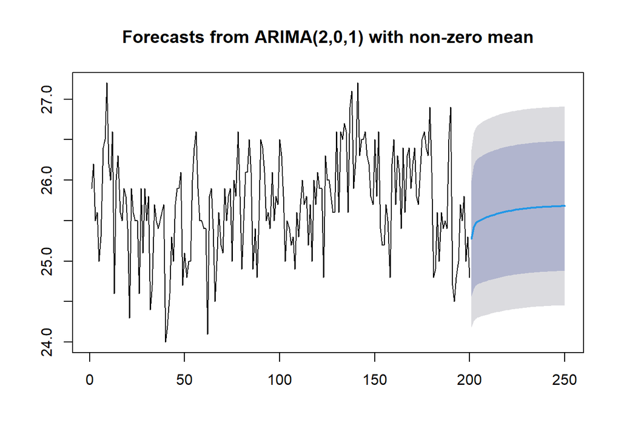

```r
data.ramalan <- ramalan$mean
plot(ramalan)
```

Berdasarkan hasil plot ramalan di atas, dapat dilihat bahwa ramalan ARIMA(2,0,1) cenderung membentuk pola tren naik, diikuti dengan selang kepercayaannya juga (lower, upper, dan point forecast membentuk tren naik untuk prediksi 50 data uji).

## **Akurasi Peramalan**

```r
perbandingan<-matrix(data=c(test_ma.ts, data.ramalan),
                     nrow = 50, ncol = 2)
colnames(perbandingan)<-c("Aktual","Hasil Forecast")
perbandingan
```

```
##        Aktual Hasil Forecast
##  [1,] 25.6000       25.27889
##  [2,] 25.3000       25.41711
##  [3,] 25.6000       25.46387
##  [4,] 25.4000       25.48565
##  [5,] 26.5000       25.50021
##  [6,] 26.3000       25.51231
##  [7,] 26.1000       25.52327
##  [8,] 27.0000       25.53346
##  [9,] 27.0000       25.54300
## [10,] 26.3000       25.55196
## [11,] 26.4000       25.56038
## [12,] 26.5000       25.56830
## [13,] 27.1000       25.57574
## [14,] 27.3000       25.58272
```

[output cut: 36 more lines]

```r
accuracy(data.ramalan,as.numeric(test_ma.ts))
```

```
##                ME     RMSE       MAE      MPE    MAPE
## Test set 0.630853 1.019866 0.8435116 2.313652 3.17038
```

Performa model dalam memprediksi data uji juga terbilang sudah baik. Karena MAPE yang dihasilkan = 3.17% < 10%. Sehingga terbukti, bahwa model yang dibangun dari data latih **tidak mengalami overfitting** (pas hanya pada data latih, tapi di data ujinya bobrok)

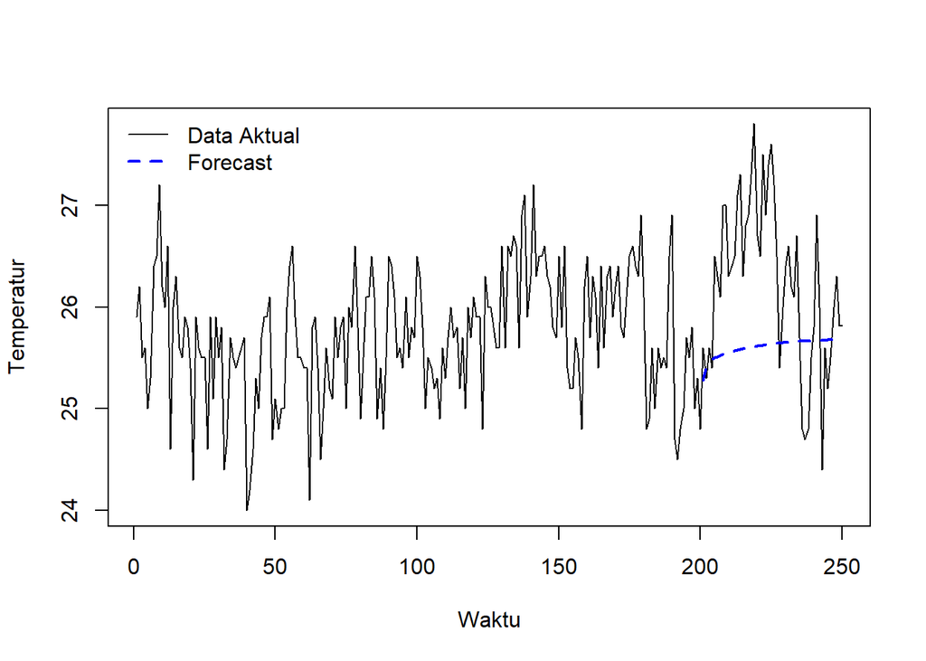

```r
ts.plot(data.ts, col = "black", lty = 1,
        xlab = "Waktu", ylab = "Temperatur")

lines(201:250, data.ramalan, col = "blue", lty = 2, lwd = 2)
legend("topleft",
       legend = c("Data Aktual", "Forecast"),
       col = c("black", "blue"),
       lty = c(1,2,3), lwd = c(1,2,1), bty = "n")
```